# Distance-based learning with manydist and tidymodels

Author

Alfonso Iodice D’Enza

```r
set.seed(123)
rm(list = ls())
devtools::load_all("../")
```

```
OK: All competitor packages are already installed.
```

```
Competitor packages loaded successfully:
 [1] "proxy"        "parallelDist" "Rfast"        "klaR"         "arules"
 [6] "cluster"      "FD"           "StatMatch"    "gower"        "clustMixType"
```

```r
# library(manydist)
library(tidyverse)
library(tidymodels)
library(palmerpenguins)
```

# 1 Introduction

The **manydist** package provides a flexible framework for distance-based learning with continuous, categorical, and mixed-type predictors. Its core function `mdist()` computes mixed-variable dissimilarities under a range of presets and custom specifications, while the `MDist` class stores both the resulting distance matrix and the associated metadata. The package also integrates with the **tidymodels** ecosystem through a recipe step, `step_mdist()`, and a custom distance-based nearest-neighbour model, `nearest_neighbor_dist()`.

This vignette illustrates the main functionalities of the package:

1. computing mixed-type distances with `mdist()`;
2. assessing variable influence with `lovo_mdist()`;
3. comparing diagnostics across methods with `compare_lovo_mdist()`;
4. creating distance-based representations with `step_mdist()`;
5. fitting and tuning a KNN model with `nearest_neighbor_dist()` and `tune_grid()`.

The focus is on *classification* of penguin species, but the same ideas apply to other supervised or unsupervised tasks that rely on pairwise distances.

# 2 Data

We start from the `penguins` data and remove rows with missing values.

```r
penguins_clean <- penguins |>
  drop_na()

penguins_clean |>
  count(species)
```

```
# A tibble: 3 × 2
  species       n
  <fct>     <int>
1 Adelie      146
2 Chinstrap    68
3 Gentoo      119
```

# 3 Computing mixed-type distances with `mdist()`

The main entry point of the package is `mdist()`, which computes a mixed-variable dissimilarity according to a chosen preset or custom specification.

```r
d_obj_all <- mdist(
  x = penguins_clean |> select(-species),
  preset = "unbiased_dependent"
)

d_obj_all
```

```
MDist object
  preset : unbiased_dependent
  number of observations : 333
  number of continuous variables   : 5
  number of categorical variables   : 2
  parameters:
    - continuous distance method: manhattan
    - categorical distance method: tot_var_dist
    - scaling for continuous vars: pc_scores
    - commensurability adjustment: TRUE
```

The resulting object stores the distance matrix together with the distance specification.

```r
class(d_obj_all)
```

```
[1] "MDist" "R6"
```

```r
dim(as.matrix(d_obj_all$distance))
```

```
[1] 333 333
```

# 4 Variable diagnostics with `lovo_mdist()`

The function `lovo_mdist()` provides a leave-one-variable-out diagnostic. For each predictor, the function recomputes the distance after removing that variable and compares the resulting structure with the full-distance solution.

```r
lovo_res <- lovo_mdist(
  x = penguins_clean |> select(-species),
  preset = "unbiased_dependent"
)

summary(lovo_res)
```

```
Summary of MDistLOVO
  preset : unbiased_dependent
  dims   : 2
  n_obs  : 333

MAD:
  range [1.0000, 1.2957], mean 1.0446
Alienation Coefficient (AC):
  range [0.0363, 0.5269], mean 0.1999

Top by MAD:
# A tibble: 5 × 2
  variable          mad_importance
  <chr>                      <dbl>
1 sex                         1.30
2 bill_length_mm              1.01
3 body_mass_g                 1.00
4 bill_depth_mm               1.00
5 flipper_length_mm           1.00

Top by AC:
# A tibble: 5 × 2
  variable       ac_importance
  <chr>                  <dbl>
1 sex                   0.527
2 island                0.378
3 bill_depth_mm         0.190
4 body_mass_g           0.122
5 bill_length_mm        0.0933
```

A graphical summary is also available through `autoplot()`.

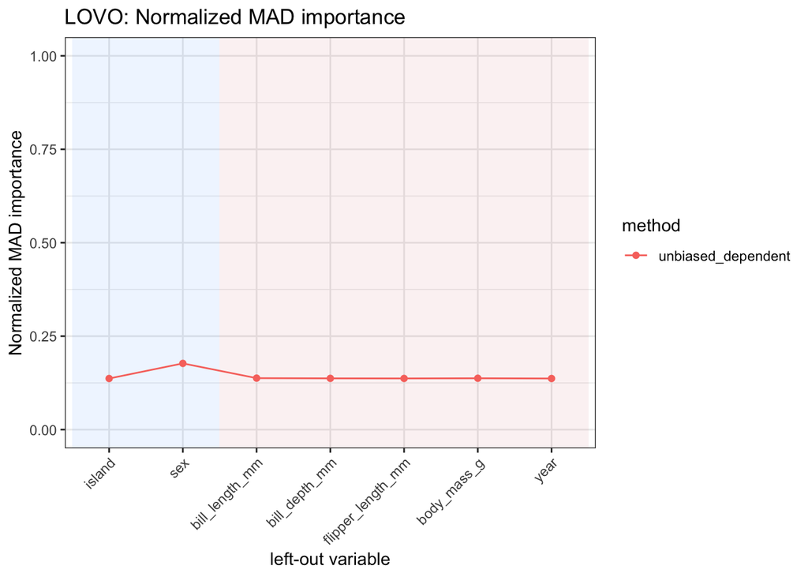

```r
autoplot(lovo_res, "mad_normalized")
```

# 5 Comparing distance specifications with `compare_lovo_mdist()`

The function `compare_lovo_mdist()` extends the LOVO diagnostic to multiple distance specifications. This makes it possible to compare how variable contributions change across alternative mixed-type distances.

In the example below, we compare:

- `"gower"`, a standard mixed-type distance;
- `"unbiased_dependent"`, an association-aware distance that enforces commensurability;
- a custom specification based on Manhattan distance for numeric variables and Hennig–Liao distance for categorical variables.

```r
lovo_cmp <- compare_lovo_mdist(
  x = penguins_clean |> select(-species),
  methods = list(
    gower = list(
      preset = "gower"
    ),
    u_dep = list(
      preset = "unbiased_dependent"
    ),
    custom = list(
      distance_cont = "manhattan",
      distance_cat  = "HL",
      commensurable = FALSE
    )
  )
)

lovo_cmp
```

```
MDistLOVOCompare object
  methods: gower, u_dep, custom
  dims   : 2
  n_obs  : 333
  rows   : 21

Top variables by MAD within each method:
# A tibble: 9 × 4
  method variable          mad_importance ac_importance
  <fct>  <chr>                      <dbl>         <dbl>
1 gower  island                    0.0730       0.240
2 gower  sex                       0.0697       0.378
3 gower  year                      0.0481       0.0501
4 u_dep  sex                       1.30         0.527
5 u_dep  bill_length_mm            1.01         0.0933
6 u_dep  body_mass_g               1.00         0.122
7 custom body_mass_g             913.           0.416
8 custom flipper_length_mm        15.9          0.00908
9 custom bill_length_mm            6.27         0.00994
```

```r
summary(lovo_cmp)
```

```
Summary of MDistLOVOCompare
  methods: gower, u_dep, custom
  dims   : 2
  n_obs  : 333

# A tibble: 3 × 7
  method mad_min  mad_max mad_mean   ac_min ac_max ac_mean
  <fct>    <dbl>    <dbl>    <dbl>    <dbl>  <dbl>   <dbl>
1 gower   0.0261   0.0730   0.0431 0.0501    0.378  0.141
2 u_dep   1.000    1.30     1.04   0.0363    0.527  0.200
3 custom  0.883  913.     134.     0.000653  0.416  0.0627
```

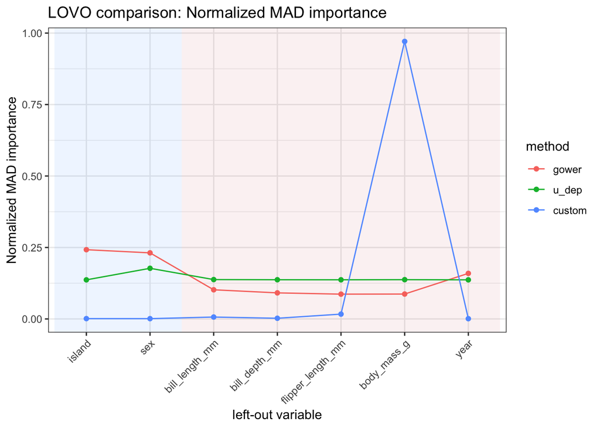

```r
autoplot(lovo_cmp, metric = "mad_normalized")
```

# 6 Distance-based KNN in base R

We now move to a simple predictive setting and create a stratified train/test split.

```r
set.seed(123)
peng_split <- initial_split(penguins_clean, strata = species)
peng_train <- training(peng_split)
peng_test  <- testing(peng_split)

dim(peng_train)
```

```
[1] 249   8
```

```r
dim(peng_test)
```

```
[1] 84  8
```

We separate predictors and outcome:

```r
x_train <- peng_train |>
  select(-species)
x_test  <- peng_test |>
  select(-species)
y_train <- peng_train$species
y_test  <- peng_test$species
```

We compute train-to-test distances with `mdist()`.

```r
d_obj <- mdist(
  x = x_train,
  new_data = x_test,
  preset = "unbiased_dependent"
)

d_obj
```

```
MDist object
  preset : unbiased_dependent
  number of training observations : 249
  number of test observations     : 84
  number of continuous variables   : 5
  number of categorical variables   : 2
  parameters:
    - continuous distance method: manhattan
    - categorical distance method: tot_var_dist
    - scaling for continuous vars: pc_scores
    - commensurability adjustment: TRUE
```

```r
distance_matrix <- as.matrix(d_obj$distance)
dim(distance_matrix)
```

```
[1]  84 249
```

These distances can be used directly in a minimal KNN implementation.

```r
n_neighbours <- 5

nn_idx <- apply(distance_matrix, 1, function(d) order(d)[1:n_neighbours])

pred_base <- apply(nn_idx, 2, function(idx) {
  names(which.max(table(y_train[idx])))
})

mean(pred_base == y_test)
```

```
[1] 0.9761905
```

# 7 Distance-based representations with `step_mdist()`

To integrate with `tidymodels`, manydist provides the recipe step `step_mdist()`, which transforms the predictor set into a distance-based representation.

```r
peng_rec <- recipe(species ~ ., data = peng_train) |>
  step_mdist(all_predictors(), preset = "unbiased_dependent")

peng_rec
```

```
Step: mdist
  role:        predictor
  trained:     FALSE

  preset:      unbiased_dependent
  (arguments handled internally by preset)
```

```r
prepped_rec <- peng_rec |>
  prep()
```

```r
train_dist <- bake(prepped_rec, new_data = peng_train)
test_dist  <- bake(prepped_rec, new_data = peng_test)
```

# 8 Distance-based KNN with `nearest_neighbor_dist()`

The package also provides a custom parsnip model, `nearest_neighbor_dist()`, with a `"precomputed"` engine.

```r
knn_spec <- nearest_neighbor_dist(
  mode = "classification",
  neighbors = 5
) |>
  set_engine("precomputed")

knn_spec
```

```
nearest neighbor dist Model Specification (classification)

Main Arguments:
  neighbors = 5

Computational engine: precomputed
```

We can combine the recipe and the model in a workflow.

```r
peng_wf <- workflow() |>
  add_recipe(peng_rec) |>
  add_model(knn_spec)

peng_wf
```

```
══ Workflow ════════════════════════════════════════════════════════════════════
Preprocessor: Recipe
Model: nearest_neighbor_dist()

── Preprocessor ────────────────────────────────────────────────────────────────
1 Recipe Step

• step_mdist()

── Model ───────────────────────────────────────────────────────────────────────
nearest neighbor dist Model Specification (classification)

Main Arguments:
  neighbors = 5

Computational engine: precomputed
```

```r
peng_fit <- peng_wf |>
  fit(data = peng_train)
```

Predictions and performance evaluation are then straightforward.

```r
peng_pred <- predict(peng_fit, new_data = peng_test, type = "prob") |>
  bind_cols(
    predict(peng_fit, new_data = peng_test, type = "class"),
    peng_test |> select(species)
  )

peng_pred |>
  head()
```

```
# A tibble: 6 × 5
  .pred_Adelie .pred_Chinstrap .pred_Gentoo .pred_class species
         <dbl>           <dbl>        <dbl> <fct>       <fct>
1          1               0              0 Adelie      Adelie
2          0.8             0.2            0 Adelie      Adelie
3          1               0              0 Adelie      Adelie
4          1               0              0 Adelie      Adelie
5          1               0              0 Adelie      Adelie
6          1               0              0 Adelie      Adelie
```

```r
peng_pred |>
  accuracy(truth = species, estimate = .pred_class)
```

```
# A tibble: 1 × 3
  .metric  .estimator .estimate
  <chr>    <chr>          <dbl>
1 accuracy multiclass     0.976
```

# 9 Tuning the number of neighbors

Because `nearest_neighbor_dist()` is registered as a parsnip model, its hyperparameters can be tuned using `tune_grid()`.

```r
knn_tune_spec <- nearest_neighbor_dist(
  mode = "classification",
  neighbors = tune()
) |>
  set_engine("precomputed")

knn_tune_spec
```

```
nearest neighbor dist Model Specification (classification)

Main Arguments:
  neighbors = tune()

Computational engine: precomputed
```

```r
peng_wf_tune <- workflow() |>
  add_recipe(peng_rec) |>
  add_model(knn_tune_spec)
```

```r
set.seed(123)
peng_folds <- vfold_cv(peng_train, v = 5, strata = species)

k_grid <- tibble(neighbors = seq(3, 15, by = 2))
k_grid
```

```
# A tibble: 7 × 1
  neighbors
      <dbl>
1         3
2         5
3         7
4         9
5        11
6        13
7        15
```

```r
peng_metrics <- metric_set(accuracy)

tuned_knn <- tune_grid(
  peng_wf_tune,
  resamples = peng_folds,
  grid = k_grid,
  metrics = peng_metrics
)
```

```r
collect_metrics(tuned_knn)
```

```
# A tibble: 7 × 7
  neighbors .metric  .estimator  mean     n std_err .config
      <dbl> <chr>    <chr>      <dbl> <int>   <dbl> <chr>
1         3 accuracy multiclass 0.984     5 0.00774 pre0_mod1_post0
2         5 accuracy multiclass 0.988     5 0.00494 pre0_mod2_post0
3         7 accuracy multiclass 0.984     5 0.00403 pre0_mod3_post0
4         9 accuracy multiclass 0.984     5 0.00398 pre0_mod4_post0
5        11 accuracy multiclass 0.984     5 0.00398 pre0_mod5_post0
6        13 accuracy multiclass 0.984     5 0.00398 pre0_mod6_post0
7        15 accuracy multiclass 0.984     5 0.00398 pre0_mod7_post0
```

```r
show_best(tuned_knn, metric = "accuracy")
```

```
# A tibble: 5 × 7
  neighbors .metric  .estimator  mean     n std_err .config
      <dbl> <chr>    <chr>      <dbl> <int>   <dbl> <chr>
1         5 accuracy multiclass 0.988     5 0.00494 pre0_mod2_post0
2         9 accuracy multiclass 0.984     5 0.00398 pre0_mod4_post0
3        11 accuracy multiclass 0.984     5 0.00398 pre0_mod5_post0
4        13 accuracy multiclass 0.984     5 0.00398 pre0_mod6_post0
5        15 accuracy multiclass 0.984     5 0.00398 pre0_mod7_post0
```

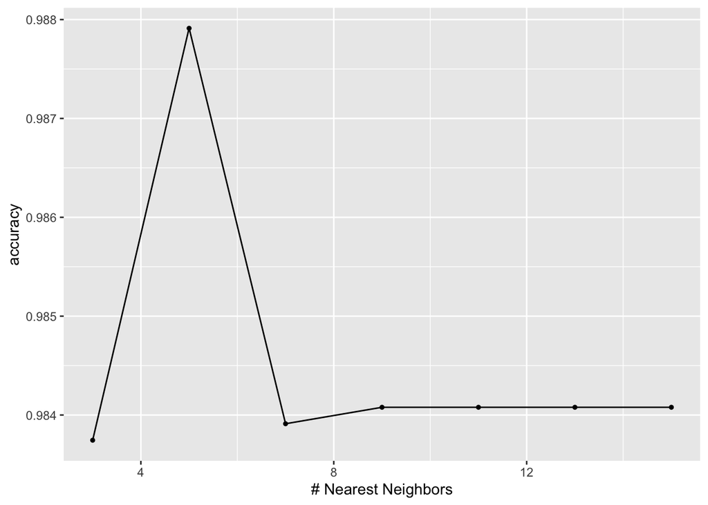

```r
autoplot(tuned_knn)
```

After selecting the best value of `k`, the workflow can be finalized and re-fitted on the training set.

```r
best_k <- select_best(tuned_knn, metric = "accuracy")

final_wf <- peng_wf_tune |>
  finalize_workflow(best_k)

final_fit <- final_wf |>
  fit(data = peng_train)

final_pred <- predict(final_fit, new_data = peng_test, type = "class") |>
  bind_cols(peng_test |> select(species))

final_pred |>
  accuracy(truth = species, estimate = .pred_class)
```

```
# A tibble: 1 × 3
  .metric  .estimator .estimate
  <chr>    <chr>          <dbl>
1 accuracy multiclass     0.976
```

# 10 Summary

In this vignette we showed how **manydist** can be used for distance-based learning on mixed data through:

- mixed-type distance computation with `mdist()`;
- variable diagnostics with `lovo_mdist()`;
- method comparison with `compare_lovo_mdist()`;
- recipe-based representations with `step_mdist()`;
- distance-based KNN modeling and tuning with `nearest_neighbor_dist()`.